# **Temas Selectos de Econofísica: Modelado de agentes económicos con Python.**

### Análisis de los reportes de agentes: Comparación de 5 escenarios

- De los agentes hemos recolectado la riqueza y el número de rondas consecutivas sin realizar transacciones.
- Podemos comparar los 5 tamaños de población diferentes graficando el número promedio de rondas consecutivas sin transacciones para cada tamaño poblacional.
- Es importante notar que estamos agregando información múltiples veces: primero, calculamos el promedio de todos los agentes para cada repetición individual.
- Luego, graficamos esos promedios de todas las repeticiones, con una banda de error que muestra el intervalo de confianza del 95% de ese primer promedio (sobre todos los agentes).
- Por lo tanto, esta banda de error representa la incertidumbre del valor medio del número de rondas consecutivas sin transacción para cada tamaño de población.

```python
# Calcular el promedio de la riqueza y el número de rondas consecutivas
# sin transacciones para todos los agentes en cada episodio.

agg_results_df = (
    results_5s_df.groupby(["iteration", "n", "Step"])
    .agg({"Wealth": "mean", "Steps_not_given": "mean"})
    .reset_index())
```

```python
agg_results_df
```

|  | iteration | n | Step | Wealth | Steps_not_given |
| --- | --- | --- | --- | --- | --- |
| 0 | 0 | 5 | 0 | NaN | NaN |
| 1 | 0 | 5 | 1 | 1.0 | 0.0000 |
| 2 | 0 | 5 | 2 | 1.0 | 0.6000 |
| 3 | 0 | 5 | 3 | 1.0 | 1.2000 |
| 4 | 0 | 5 | 4 | 1.0 | 2.2000 |
| ... | ... | ... | ... | ... | ... |
| 12620 | 24 | 80 | 96 | 1.0 | 1.6125 |
| 12621 | 24 | 80 | 97 | 1.0 | 1.7875 |
| 12622 | 24 | 80 | 98 | 1.0 | 1.7625 |
| 12623 | 24 | 80 | 99 | 1.0 | 1.8625 |
| 12624 | 24 | 80 | 100 | 1.0 | 1.6625 |

12625 rows × 5 columns

[output not shown]

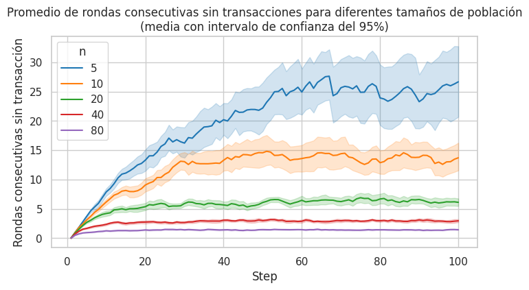

```python
# Crear un gráfico de líneas con barras de error
g = sns.lineplot(data=agg_results_df, x="Step", y="Steps_not_given", hue="n", palette="tab10")
g.figure.set_size_inches(8, 4)
g.set(title="Promedio de rondas consecutivas sin transacciones para "
    "diferentes tamaños de población\n(media con intervalo de confianza del 95%)",
    ylabel="Rondas consecutivas sin transacción")
```

- Se puede observar claramente que, a medida que disminuye el número de agentes, aumenta el número de rondas consecutivas sin una transacción.
- Esto se debe a que los agentes tienen menos interacciones entre sí y, por lo tanto, la riqueza de un agente tiene menos probabilidades de cambiar.

### Pasos generales para analizar los resultados

Existen muchos otros análisis posibles basados en las políticas, escenarios e incertidumbres que te interese explorar.

En general, puedes seguir estos pasos para realizar tu propio análisis:

1. Determina las métricas que deseas analizar. Añádelas como reporteros de modelo y agente al `datacollector` de tu modelo.
2. Determina los parámetros de entrada que deseas variar. Añádelos como parámetros a la función `batch_run`, utilizando rangos o listas para probar diferentes valores.
3. Determina los hiperparámetros de la función `batch_run`. Define el número de iteraciones, el número de procesos, el número de pasos, el periodo de recolección de datos, etc.
4. Ejecuta la función `batch_run` y guarda los resultados.
5. Transforma, filtra y agrega los resultados para obtener los datos que deseas analizar.
6. Elige el tipo de gráfico, qué mostrar en los ejes x e y, qué columnas usar para el color. Seaborn también tiene una increíble [Galería de Ejemplos](https://seaborn.pydata.org/examples/index.html).
7. Grafica los datos y analiza los resultados.

# Extensiones del modelo base:

### 1. Modelo de intercambio aleatorio con propensión al ahorro

Un **factor de propensión al ahorro** λ fue introducido en el modelo de intercambio aleatorio (Chakraborti y Chakrabarti, 2000), en el cual cada agente en el tiempo *t* ahorra una fracción λ de su dinero $m_i(t)$ y comercia aleatoriamente con el resto:

$ m_i(t + 1) = \lambda m_i(t) + \epsilon_{ij}(1 - \lambda)(m_i(t) + m_j(t)) $ $ m_j(t + 1) = \lambda m_j(t) + (1 - \epsilon_{ij})(1 - \lambda)(m_i(t) + m_j(t)) $

donde

$ \Delta m = (1 - \lambda)\left[\epsilon_{ij}(m_i(t) + m_j(t)) - m_i(t)\right] $

y donde $\epsilon_{ij}$ es una fracción aleatoria.  
Por definición, $\lambda$ es una fracción propia, es decir, $0 \leq \lambda \leq 1$.

### 1. Modelo de intercambio aleatorio con propensión al ahorro

[figure not shown]

Tomado de: Chakrabarti, B. K., Chakraborti, A., Chakravarty, S. R., & Chatterjee, A. (2013). Econophysics of income and wealth distributions. Cambridge University Press.

### 2. Modelo con deuda

[figure not shown]

Tomado de: Chakrabarti, B. K., Chakraborti, A., Chakravarty, S. R., & Chatterjee, A. (2013). Econophysics of income and wealth distributions. Cambridge University Press.

### 3. Distribuciones generalizadas para modelar la distribución del ingreso y riqueza

- McDonald, J. B., & Ransom, M. (2008). The generalized beta distribution as a model for the distribution of income: estimation of related measures of inequality. In Modeling income distributions and Lorenz curves (pp. 147-166). New York, NY: Springer New York.
- Moghaddam, M. D., Mills, J., & Serota, R. A. (2020). From a stochastic model of economic exchange to measures of inequality. Physica A: Statistical Mechanics and its Applications, 559, 125047.
- Clementi, F., Gallegati, M., Kaniadakis, G., & Landini, S. (2016). κ-generalized models of income and wealth distributions: A survey. The European Physical Journal Special Topics, 225, 1959-1984.

# ¡Gracias!

**email: andgarm.n@gmail.com**

**sitio: https://sites.google.com/view/andresgm/home.**